# Modern concepts and methods in Macroecology and Biogeography

Day 1: Basics and spatial data in R

Patrick Weigelt, Pierre Denelle & Holger Kreft

April 10th, 2024

*back to overview*

# 1. Preparation

## a) Prepare your system for exchanging data

Set the format your computer uses to display numbers to English format for exchanging data with others:

- Decimal symbol: ” . ”
- Digit grouping symbol: ” , ”
- List separator: ” , ”

## b) Install software

- Get QGIS from https://www.qgis.org/
- Get R from https://cran.r-project.org/
- Get RStudio from https://www.rstudio.com/products/rstudio/download/

## c) Create a new project in RStudio

*Do this only once for the entire practical part of the class and once again for your project in the end but not for each session separately*

- Open RStudio
- File | New Project
- Select *either* ‘New Directory’ or ‘Existing Directory’  
  this will be the working folder for our course (on your computer)
- Navigate to the prospective project folder on your computer (e.g. ’~Documents/Courses/Macroecology)
- Name your project
- Within your project’s folder, create three sub-folders:
  - data
  - code
  - figures
- Create a new empty R script: File | New File | R script
- Type: # Day 1: getting started
- Save file (in ~/code): “0_Code_Day1.R”
- Start coding!

If you want to visualize this tutorial in the viewer inside RStudio (to save space on your screen) run the following chunk of code:

```r
install.packages("rstudioapi") # install an R-package required for this step
dir <- tempfile()
dir.create(dir)
download.file("https://gift.uni-goettingen.de/mcmmb/index.html", destfile = file.path(dir, "index.html"))
download.file("https://gift.uni-goettingen.de/mcmmb/Day1.html", destfile = file.path(dir, "Day1.html"))
htmlFile <- file.path(dir, "Day1.html")
rstudioapi::viewer(htmlFile)
```

Now you can conveniently copy code from the viewer into your script.

# 2. Getting started

**Using R as a calculator**

```r
# use the console to do simple calculations
2 + 2
2 * 2
8 / 2
6 - 2
sqrt(16) # sqrt() is a function
16^(1/2)
2^2
1/2 ^ (-2)
log10(10000)
```

What is the answer of each of the operations?

**Assign a value to an object**

*Numbers*

```r
a <- 4
b <- sqrt(16)
number_3 <- 2 * 2
```

```r
a
```

```
## [1] 4
```

```r
number_3
```

```
## [1] 4
```

```r
a*b
```

```
## [1] 16
```

```r
number_3 / b
```

```
## [1] 1
```

*Character strings*

```r
text_a <- "Hello"
text_a
```

```
## [1] "Hello"
```

```r
text_a <- "Good bye" # overwrite the object
text_a
```

```
## [1] "Good bye"
```

In R Studio current objects are listed at the top-right corner. For seeing the stored objects in the console use:

```r
ls()
```

```
## [1] "a"        "b"        "number_3" "text_a"
```

# 3. Getting help in R

`?function.name` `??keyword`

```r
?sqrt # will open help page in Help tab of RStudio or browser
??squareroot
??`install package` # Or use google
```

# 4. Data structures and indexing

## a) Numbers & characters

*single values*

```r
mode(a)
```

```
## [1] "numeric"
```

```r
str(a)
```

```
##  num 4
```

```r
mode(text_a)
```

```
## [1] "character"
```

```r
str(text_a)
```

```
##  chr "Good bye"
```

## b) Vectors

*sequences of values of the same mode*

**Create a vector of numbers**

```r
vector_1 <- c(1,5,6,3.4,10,11)
vector_1
```

```
## [1]  1.0  5.0  6.0  3.4 10.0 11.0
```

**Indexing and modifying a vector**

```r
vector_1[3]
```

```
## [1] 6
```

```r
vector_1[3] <- 5
vector_1[3]
```

```
## [1] 5
```

**Creating a sequence of numbers**

```r
vector_2 <- c(1:6)
vector_2
```

```
## [1] 1 2 3 4 5 6
```

```r
vector_2 <- seq(1, 12, by=2) # overwriting
vector_2
```

```
## [1]  1  3  5  7  9 11
```

```r
vector_2 <- seq(1, 11, length.out = 6) # overwriting
vector_2
```

```
## [1]  1  3  5  7  9 11
```

```r
vector_3 <- rep(c(1,2),3) # repeats c(1,2) three times
vector_3
```

```
## [1] 1 2 1 2 1 2
```

```r
vector_3 <- rep(c(1,2),each=3) # repeats each element of c(1,2) three times
vector_3
```

```
## [1] 1 1 1 2 2 2
```

**Create a vector of character strings**

```r
vector_4 <- c("blue","red","green","yellow","grey","black")
vector_4
```

```
## [1] "blue"   "red"    "green"  "yellow" "grey"   "black"
```

```r
vector_4[4]
```

```
## [1] "yellow"
```

```r
mode(vector_4)
```

```
## [1] "character"
```

```r
length(vector_2)
```

```
## [1] 6
```

```r
mode(vector_2)
```

```
## [1] "numeric"
```

You can do calculations with numeric vectors just like with values

```r
vector_2
```

```
## [1]  1  3  5  7  9 11
```

```r
vector_2^2
```

```
## [1]   1   9  25  49  81 121
```

```r
vector_5 <- vector_1 + vector_2
vector_5
```

```
## [1]  2.0  8.0 10.0 10.4 19.0 22.0
```

You can apply functions to vectors

```r
mean(vector_2) # function for calculating the mean
```

```
## [1] 6
```

```r
sd(vector_2)   # standard deviation
```

```
## [1] 3.741657
```

*Functions require a certain input structure like here a vector*

```r
mean(c(3,6))
```

```
## [1] 4.5
```

```r
mean(3,6) # actually means mean(x=3, trim=6, na.rm = FALSE)
```

```
## [1] 3
```

```r
#?mean
```

**Plotting vectors**

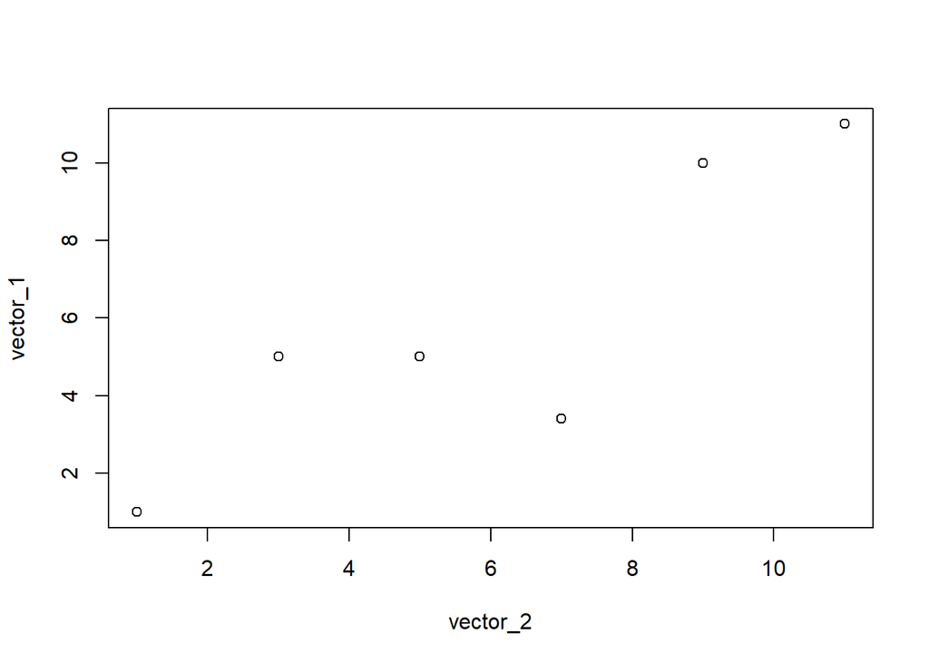

```r
plot(vector_2,vector_1)
```

There are two major ways of plotting in R: Base R like above and [ggplot2](https://www.cedricscherer.com/2019/08/05/a-ggplot2-tutorial-for-beautiful-plotting-in-r/) which we will touch upon throughout the tutorials.

## c) Arrays and matrices

*tables of values of the same mode with n dimensions (matrix = 2 dimensions)*

```r
matrix_1 <- matrix(NA, nrow = 6, ncol = 6)
matrix_1
```

```
##      [,1] [,2] [,3] [,4] [,5] [,6]
## [1,]   NA   NA   NA   NA   NA   NA
## [2,]   NA   NA   NA   NA   NA   NA
## [3,]   NA   NA   NA   NA   NA   NA
## [4,]   NA   NA   NA   NA   NA   NA
## [5,]   NA   NA   NA   NA   NA   NA
## [6,]   NA   NA   NA   NA   NA   NA
```

```r
matrix_1 <- matrix(1:36, nrow = 6, ncol = 6) # Filling a matrix with a sequence of values
matrix_1
```

```
##      [,1] [,2] [,3] [,4] [,5] [,6]
## [1,]    1    7   13   19   25   31
## [2,]    2    8   14   20   26   32
## [3,]    3    9   15   21   27   33
## [4,]    4   10   16   22   28   34
## [5,]    5   11   17   23   29   35
## [6,]    6   12   18   24   30   36
```

```r
matrix_2 <- matrix(1:(6*6), nrow = 6, ncol = 6, byrow = TRUE)
matrix_2
```

```
##      [,1] [,2] [,3] [,4] [,5] [,6]
## [1,]    1    2    3    4    5    6
## [2,]    7    8    9   10   11   12
## [3,]   13   14   15   16   17   18
## [4,]   19   20   21   22   23   24
## [5,]   25   26   27   28   29   30
## [6,]   31   32   33   34   35   36
```

**Indexing a matrix**

```r
matrix_2[3,5] # row,column
```

```
## [1] 17
```

```r
matrix_2[3,]  # select a row
```

```
## [1] 13 14 15 16 17 18
```

```r
matrix_2[,5]  # select a column
```

```
## [1]  5 11 17 23 29 35
```

You can do element-wise calculations with numeric matrices just like with values and vectors

```r
matrix_1 + 1
```

```
##      [,1] [,2] [,3] [,4] [,5] [,6]
## [1,]    2    8   14   20   26   32
## [2,]    3    9   15   21   27   33
## [3,]    4   10   16   22   28   34
## [4,]    5   11   17   23   29   35
## [5,]    6   12   18   24   30   36
## [6,]    7   13   19   25   31   37
```

```r
matrix_1 ^ 2
```

```
##      [,1] [,2] [,3] [,4] [,5] [,6]
## [1,]    1   49  169  361  625  961
## [2,]    4   64  196  400  676 1024
## [3,]    9   81  225  441  729 1089
## [4,]   16  100  256  484  784 1156
## [5,]   25  121  289  529  841 1225
## [6,]   36  144  324  576  900 1296
```

```r
matrix_1 + matrix_2 # matrix by matrix
```

```
##      [,1] [,2] [,3] [,4] [,5] [,6]
## [1,]    2    9   16   23   30   37
## [2,]    9   16   23   30   37   44
## [3,]   16   23   30   37   44   51
## [4,]   23   30   37   44   51   58
## [5,]   30   37   44   51   58   65
## [6,]   37   44   51   58   65   72
```

```r
matrix_1 * vector_2 # matrix by vector; vector of length 6 is recycled! In this case each column is multiplied by the vector because they have the same length
```

```
##      [,1] [,2] [,3] [,4] [,5] [,6]
## [1,]    1    7   13   19   25   31
## [2,]    6   24   42   60   78   96
## [3,]   15   45   75  105  135  165
## [4,]   28   70  112  154  196  238
## [5,]   45   99  153  207  261  315
## [6,]   66  132  198  264  330  396
```

```r
mean(matrix_1)     # mean of all values in matrix
```

```
## [1] 18.5
```

```r
colMeans(matrix_1) # mean values per column
```

```
## [1]  3.5  9.5 15.5 21.5 27.5 33.5
```

You can also do proper matrix calculations like Matrix multiplication or cross-products. For example, see [this](https://www.statmethods.net/advstats/matrix.html).

## d) data.frames

*tables of values of one mode per column*

**Create a data.frame**

```r
df_1 <- data.frame(ID = vector_2, number_1 = vector_1, colour = vector_4)
df_1
```

```
##   ID number_1 colour
## 1  1      1.0   blue
## 2  3      5.0    red
## 3  5      5.0  green
## 4  7      3.4 yellow
## 5  9     10.0   grey
## 6 11     11.0  black
```

```r
str(df_1)
```

```
## 'data.frame':    6 obs. of  3 variables:
##  $ ID      : num  1 3 5 7 9 11
##  $ number_1: num  1 5 5 3.4 10 11
##  $ colour  : chr  "blue" "red" "green" "yellow" ...
```

“colour” is a character vector

**Indexing**

```r
df_1[,3]        # by column number (also works for rows; [2,])
```

```
## [1] "blue"   "red"    "green"  "yellow" "grey"   "black"
```

```r
df_1[,"colour"] # calling by column name
```

```
## [1] "blue"   "red"    "green"  "yellow" "grey"   "black"
```

```r
df_1$colour     # calling by column name using $
```

```
## [1] "blue"   "red"    "green"  "yellow" "grey"   "black"
```

```r
df_1[,3] <- as.factor(df_1[,3]) # change column to factor
levels(df_1[,3])
```

```
## [1] "black"  "blue"   "green"  "grey"   "red"    "yellow"
```

```r
str(df_1)
```

```
## 'data.frame':    6 obs. of  3 variables:
##  $ ID      : num  1 3 5 7 9 11
##  $ number_1: num  1 5 5 3.4 10 11
##  $ colour  : Factor w/ 6 levels "black","blue",..: 2 5 3 6 4 1
```

Now “colour” is a factor, which is smaller when stored and faster to handle.

Be careful when converting factors to numeric vectors or columns!

```r
numeric_factor <- as.factor(df_1$number_1)
numeric_factor
```

```
## [1] 1   5   5   3.4 10  11
## Levels: 1 3.4 5 10 11
```

```r
as.numeric(numeric_factor)
```

```
## [1] 1 3 3 2 4 5
```

```r
as.numeric(as.character(numeric_factor))
```

```
## [1]  1.0  5.0  5.0  3.4 10.0 11.0
```

# 5. data.frame exercise

1. Imagine a field study with 5 plots (1,2,3,…) in each of 3 vegetation types (forest, shrubland, grassland).
2. Create a data.frame with 1 row per plot and 2 columns for “vegetation_type” and “plot”.
3. Every second day of a month a student visits one of the plots. Add a third column called “day” indicating when the student visits each plot: 1, 3, 5, …

Table 1: Dataframe exercise

| vegetation_type | plot | day |
| --- | --- | --- |
| forest | 1 | 1 |
| forest | 2 | 3 |
| forest | 3 | 5 |
| forest | 4 | 7 |
| forest | 5 | 9 |
| shrubland | 1 | 11 |
| shrubland | 2 | 13 |
| shrubland | 3 | 15 |
| shrubland | 4 | 17 |
| shrubland | 5 | 19 |
| grassland | 1 | 21 |
| grassland | 2 | 23 |
| grassland | 3 | 25 |
| grassland | 4 | 27 |
| grassland | 5 | 29 |

# 6. Plotting dataframes

In R, there are two major ways to plot your data: **base R** and **ggplot2**.  
There is no better way to plot things, it is rather a matter of taste, but it is quite important to know how both work.  
Let’s see this with an easy example.

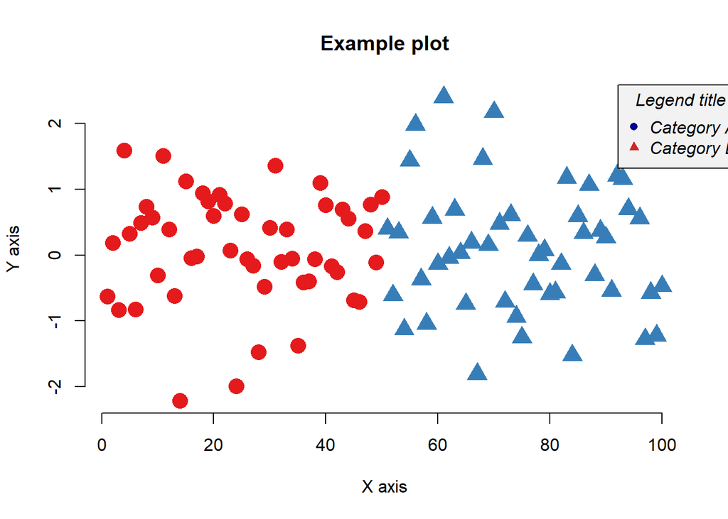

```r
library(ggplot2)

# The following R packages use color palettes are perceptually uniform, work
# with black and white, accessible to colorblind
library(RColorBrewer) # https://colorbrewer2.org/
library(viridis) # https://www.r-bloggers.com/2018/07/ggplot2-welcome-viridis/
# Example data frame
set.seed(1) # setting a random seed (to reproduce output)
ex <- data.frame(x = seq(1:100),
                 y = rnorm(100),
                 cat = c(rep("A", 50), rep("B", 50)))

par(xpd = TRUE)
plot(ex$x, ex$y,
     col = brewer.pal(n = 3, name = "Set1")[1:2][as.factor(ex$cat)],
     pch = c(16, 17)[as.factor(ex$cat)], cex = 2,
     main = "Example plot", xlab = "X axis", ylab = "Y axis",
     bty = "n")
legend("topright",
       c("Category A", "Category B"),
       inset = c(-0.1, 0),
       title = "Legend title",
       text.font = 3,
       col = c("darkblue", "firebrick3"),
       pch = c(16, 17),
       bg = "gray95")
```

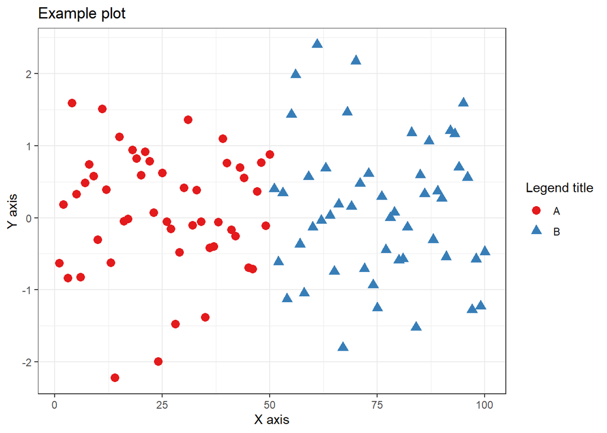

```r
# Same plot with ggplot2
ggplot(ex, aes(x, y)) +
  geom_point(aes(color = cat, shape = cat), size = 3) +
  scale_color_brewer("Legend title", palette = "Set1") +
  scale_shape_manual("Legend title",
                     values = c(16, 17)) +
  labs(title = "Example plot", x = "X axis", y = "Y axis") +
  theme_bw()
```

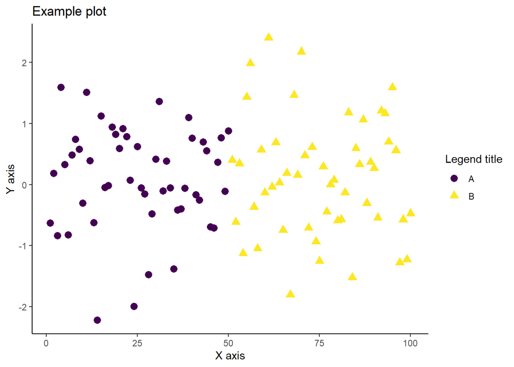

```r
# With viridis color palette
ggplot(ex, aes(x, y)) +
  geom_point(aes(color = cat, shape = cat), size = 3) +
  scale_color_viridis_d("Legend title") +
  scale_shape_manual("Legend title",
                     values = c(16, 17)) +
  labs(title = "Example plot", x = "X axis", y = "Y axis") +
  theme_classic()
```

# 7. Loading and visualising environmental raster layers

**Download the following raster layers**  
*GMTED - Digital elevation data https://topotools.cr.usgs.gov/gmted_viewer/viewer.htm*  
[Elevation above sea level (mn30_grd.zip)](http://edcintl.cr.usgs.gov/downloads/sciweb1/shared/topo/downloads/GMTED/Grid_ZipFiles/mn30_grd.zip)

*Chelsa - Climate data http://chelsa-climate.org/*  
[Annual mean temperature (CHELSA_bio10_01.tif)](https://os.zhdk.cloud.switch.ch/envicloud/chelsa/chelsa_V1/climatologies/bio/CHELSA_bio10_01.tif)  
[Mean annual precipitation (CHELSA_bio10_12.tif)](https://os.zhdk.cloud.switch.ch/envicloud/chelsa/chelsa_V1/climatologies/bio/CHELSA_bio10_12.tif)

**Extract and copy the rasters into your R-project folder ../data/**

```
## [1] "C:/Users/patty/Documents/Teaching/Macroecology/Practicals/MCMMB"
```

**Exercise: Open QGIS and add the raster layers to a project in QGIS**

**Load raster library**

```r
# install.packages("terra") # install the terra package in case not done yet
library(terra)
```

**Import global digital elevation model and plot it**

```r
elev <- rast("data/mn30_grd/") + 0 # +0 to treat raster as numeric
```

```
##
|---------|---------|---------|---------|
=========================================
```

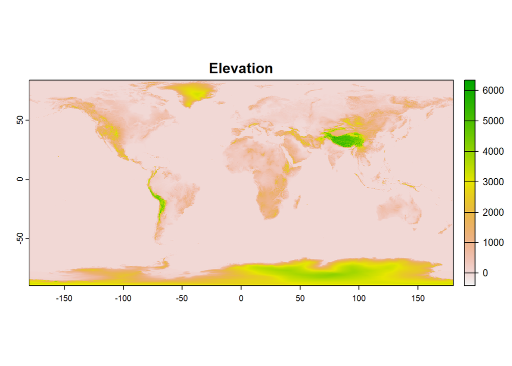

```r
par(mfrow=c(1,1))
plot(elev, main = "Elevation")
```

**Import climate data from Chelsa and plot it**

```r
bio1 <- rast("data/CHELSA_bio10_01.tif")
bio12 <- rast("data/CHELSA_bio10_12.tif")
```

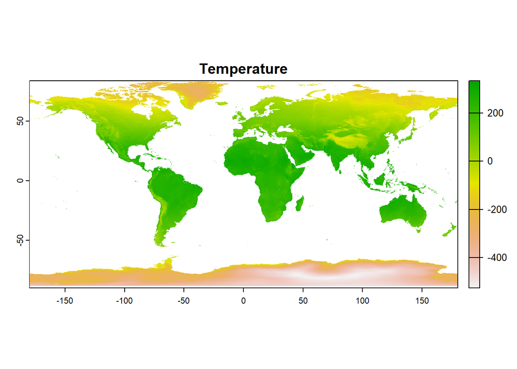

```r
plot(bio1, main = "Temperature")  # Temperature (*10 °C)
```

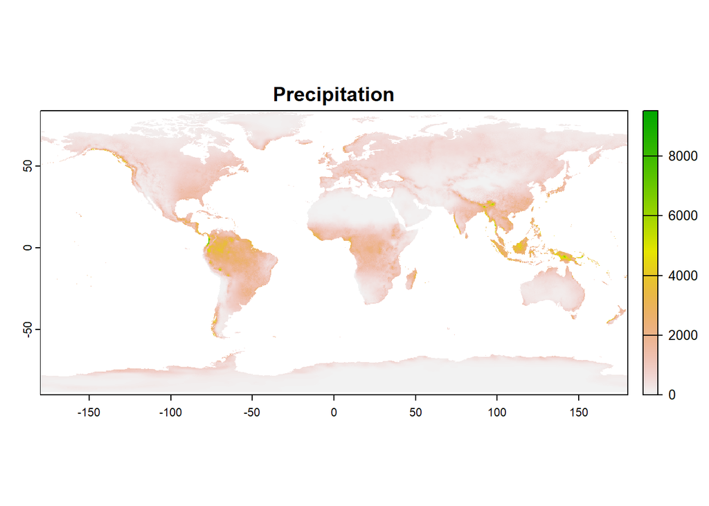

```r
plot(bio12, main = "Precipitation") # Precipitation (mm)
```

**Have a look at characteristics of the raster layers**  
`str(bio1) # long output; try it out`

```r
crs(bio1)
```

```
## [1] "GEOGCRS[\"WGS 84\",\n    ENSEMBLE[\"World Geodetic System 1984 ensemble\",\n        MEMBER[\"World Geodetic System 1984 (Transit)\"],\n        MEMBER[\"World Geodetic System 1984 (G730)\"],\n        MEMBER[\"World Geodetic System 1984 (G873)\"],\n        MEMBER[\"World Geodetic System 1984 (…
```

```r
crs(bio1)
```

```
## [1] "GEOGCRS[\"WGS 84\",\n    ENSEMBLE[\"World Geodetic System 1984 ensemble\",\n        MEMBER[\"World Geodetic System 1984 (Transit)\"],\n        MEMBER[\"World Geodetic System 1984 (G730)\"],\n        MEMBER[\"World Geodetic System 1984 (G873)\"],\n        MEMBER[\"World Geodetic System 1984 (…
```

```r
ncol(bio1)
```

```
## [1] 43200
```

```r
nrow(bio1)
```

```
## [1] 20880
```

```r
cellSize(bio1)
```

```
##
|---------|---------|---------|---------|
=========================================
```

```
## class       : SpatRaster
## dimensions  : 20880, 43200, 1  (nrow, ncol, nlyr)
## resolution  : 0.008333333, 0.008333333  (x, y)
## extent      : -180.0001, 179.9999, -90.00014, 83.99986  (xmin, xmax, ymin, ymax)
## coord. ref. : lon/lat WGS 84 (EPSG:4326)
## source      : spat_cmwGlLRCp5aVYFp_12512.tif
## varname     : CHELSA_bio10_01
## name        :         area
## min value   :     60.92067
## max value   : 854796.68750
```

30 arc seconds resolution = ~1km² at the equator

**You can do calculations with the raster layers**

```r
system.time(log_bio12 <- log10(bio12+1)) # Careful! this is computer intense and might take a long time
```

```
##
|---------|---------|---------|---------|
=========================================


|---------|---------|---------|---------|
=========================================
```

```
##    user  system elapsed
##   20.77    1.57   76.20
```

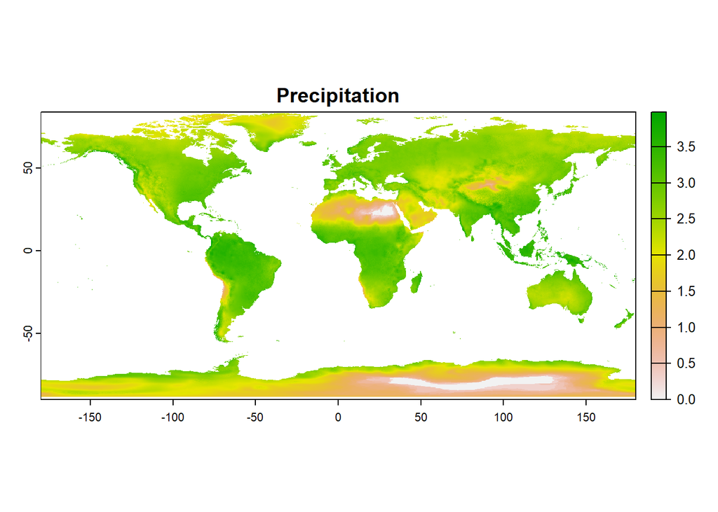

```r
plot(log_bio12, main = "Precipitation") # Log-transformed precipitation
```

```r
bio1 <- bio1/10
```

```
##
|---------|---------|---------|---------|
=========================================
```

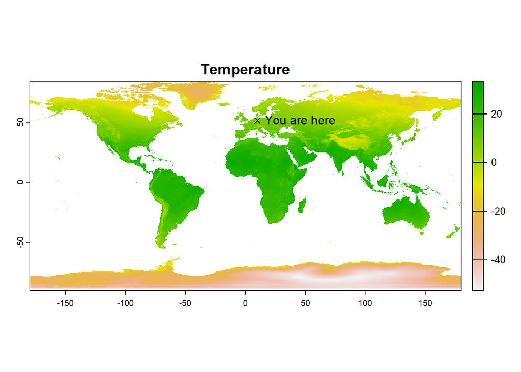

```r
plot(bio1, main = "Temperature") # Temperature (°C)
points(9.916, 51.541, pch=4) # Göttingen
text(9.916, 51.541, "You are here", pos = 4)
```